# Assignment 3

Alessandro Giulivo, Francesca Rinaldi, Martina Monciotti

12/12/2021

```r
library(ggplot2)
library(ggfortify)
library(factoextra)
library(Rtsne)
library(dplyr)
library(umap)
```

*QUESTION 1*

```r
#Read data
#setwd("C:/Users/aless/Desktop/Bioinformatics/Erasmus BCN/Data Visualisation/homeassignment")
P3<- read.delim("P3.tsv.gz", row.names=1)
P4<- read.delim("P4.tsv.gz", row.names=1)
P5<- read.delim("P5.tsv.gz", row.names=1)

#Check data
#head(P3, 5)
#head(P4, 5)
#head(P5, 5)

#Alternatives
#P3<- read.table(gzfile("P3.tsv.gz", "rt"), header= TRUE)
#P4<- read.table(gzfile("P4.tsv.gz", "rt"), header= TRUE)
#P5<- read.table(gzfile("P5.tsv.gz", "rt"), header= TRUE)
```

**QUESTION 2**

```r
treat<- read.delim("samplesheet.tsv", row.names=1)
#treat <- as.factor(readLines("samplesheet.tsv"))
#Alternatives
#treat<- read.table(("samplesheet.tsv", "rt"), header= TRUE))
table(treat)
```

```
## treat
## J-LatA2+DMSO  J-LatA2+PMA J-LatA2+SAHA  Jurkat+DMSO   Jurkat+PMA  Jurkat+SAHA
##           36           81           81           18           36           36
```

```r
treat= tidyr::separate(
  treat,
  col= label,
  into= c("cells", "drugs"),
  sep = "\\+")
```

There are 2 kinds of cells (one infected with HIV and one with a latent virus), each one is treated with DMSO, SAHA and PMA. This creates 6 different combinations, the table above shows the number of cells in each condition.

**QUESTION 3**

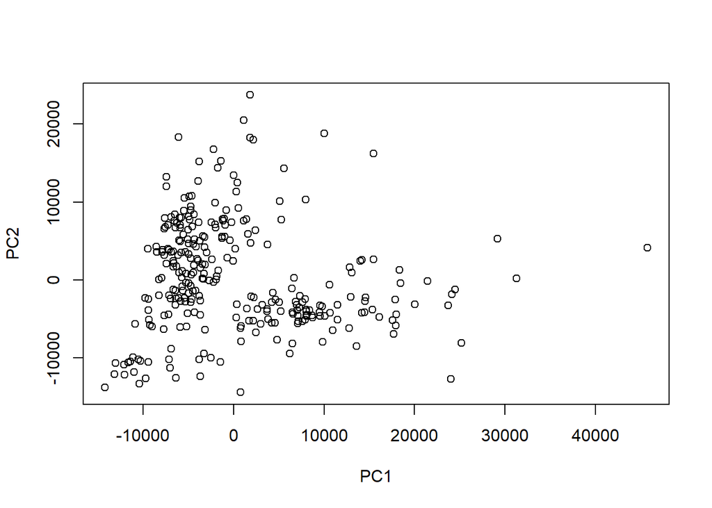

```r
X3 <- t(P3)
X4 <- t(P4)
X5 <- t(P5)

X1 = rbind(X3, X4, X5)

data <- data.frame(row.names= rownames(X1), experiment= as.factor(rep(c("A", "B", "C"), each=96)), treatment=treat)

colnames(data)<- c("experiment", "cells", "drugs")

#PCA
PCA = stats::prcomp(X1)
plot(PCA$x)
```

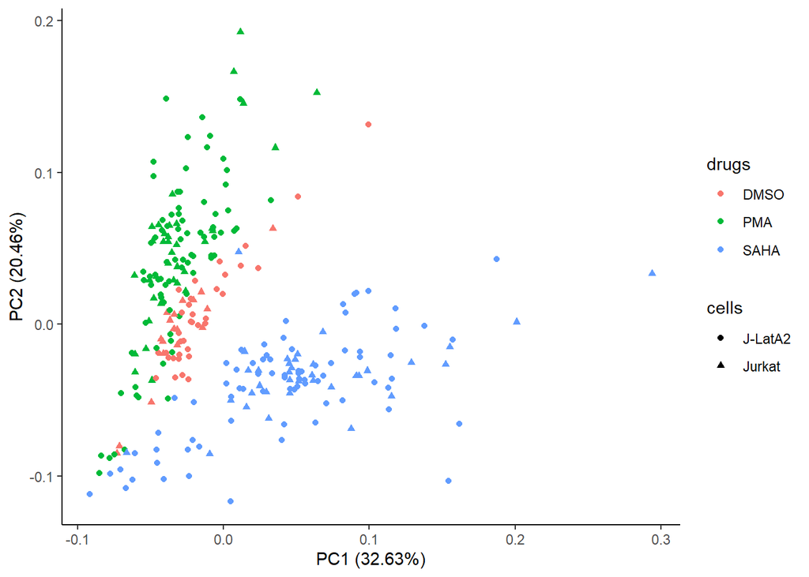

```r
#coloring by treatment
#using autoplot
ggplot2::autoplot(PCA, data = data, colour = "drugs", shape= "cells") + theme_classic()
```

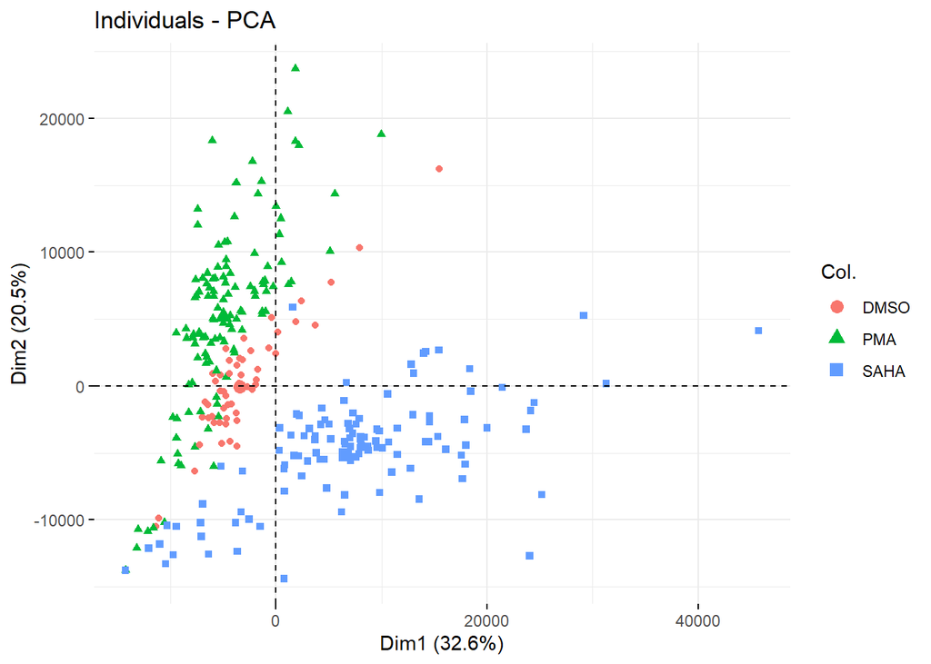

```r
#using factoextra
factoextra::fviz_pca_ind(PCA, geom = "point", col.ind = data$drugs)
```

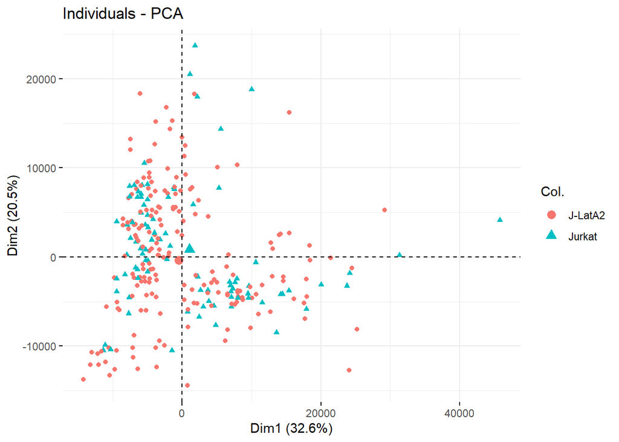

```r
factoextra::fviz_pca_ind(PCA, geom = "point", col.ind = data$cells)
```

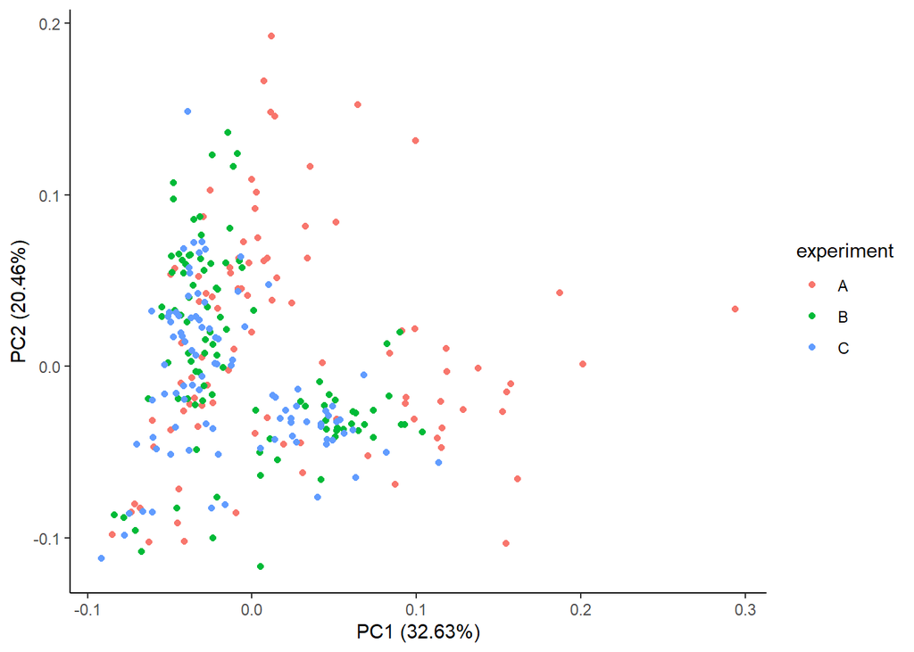

```r
#coloring by experiment
#using autoplot
ggplot2::autoplot(PCA, data = data, colour = "experiment") + theme_classic()
```

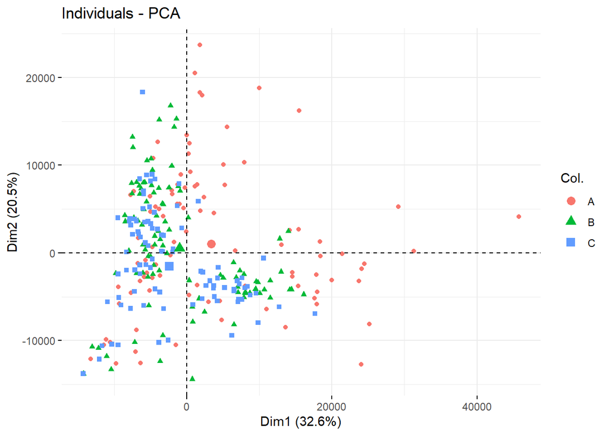

```r
#using factoextra
factoextra::fviz_pca_ind(PCA, geom = "point", col.ind = data$experiment)
```

```r
#creating scaled PCA
print(dim(X1))
```

```
## [1]   288 58780
```

```r
X1=X1[, colSums(X1)>0] ## tip: rowSums > 0
print(dim(X1))
```

```
## [1]   288 23104
```

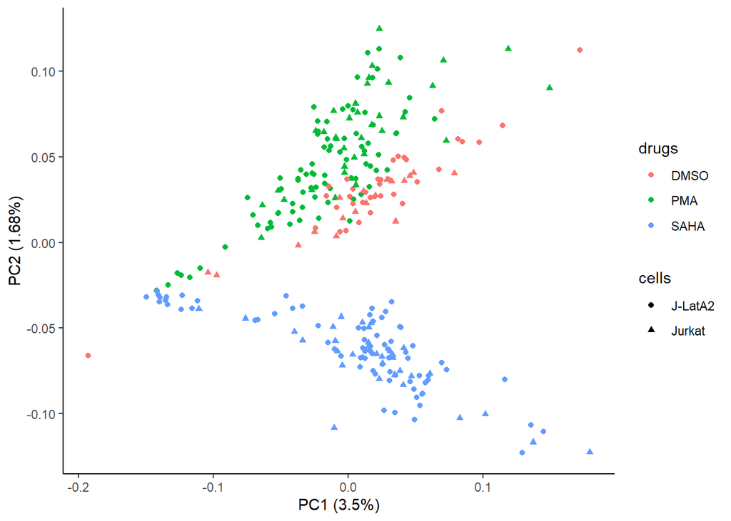

```r
pca_res_scaled <- stats::prcomp(X1, scale=TRUE)
#colored by treatment
ggplot2::autoplot(pca_res_scaled, data = data, colour = "drugs", shape= "cells") + theme_classic()
```

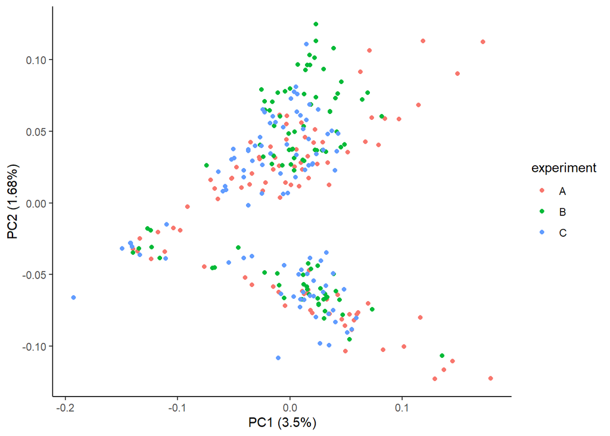

```r
#colored by experiment
ggplot2::autoplot(pca_res_scaled, data = data, colour = "experiment") + theme_classic()
```

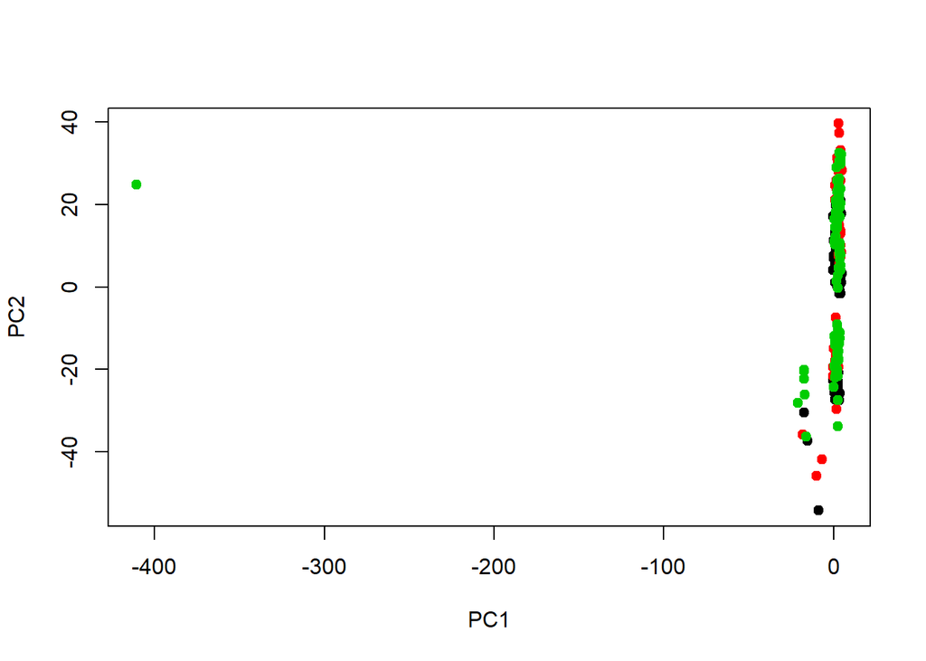

```r
#creating normalized PCA
Y1 = X1/rowSums(X1)
normpca <- stats::prcomp(Y1, scale=TRUE)
#colored by experiment
plot(normpca$x, pch=19, col=data$experiment)
```

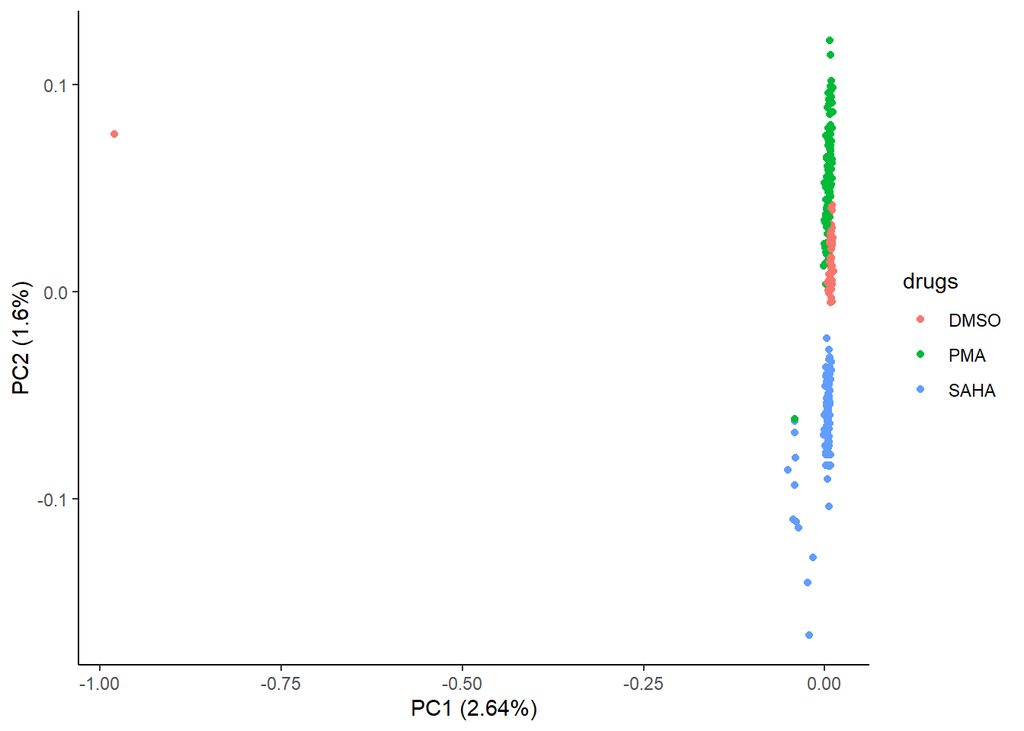

```r
#colored by treatment, using autoplot
ggplot2::autoplot(normpca, data=data, colour="drugs") + theme_classic()
```

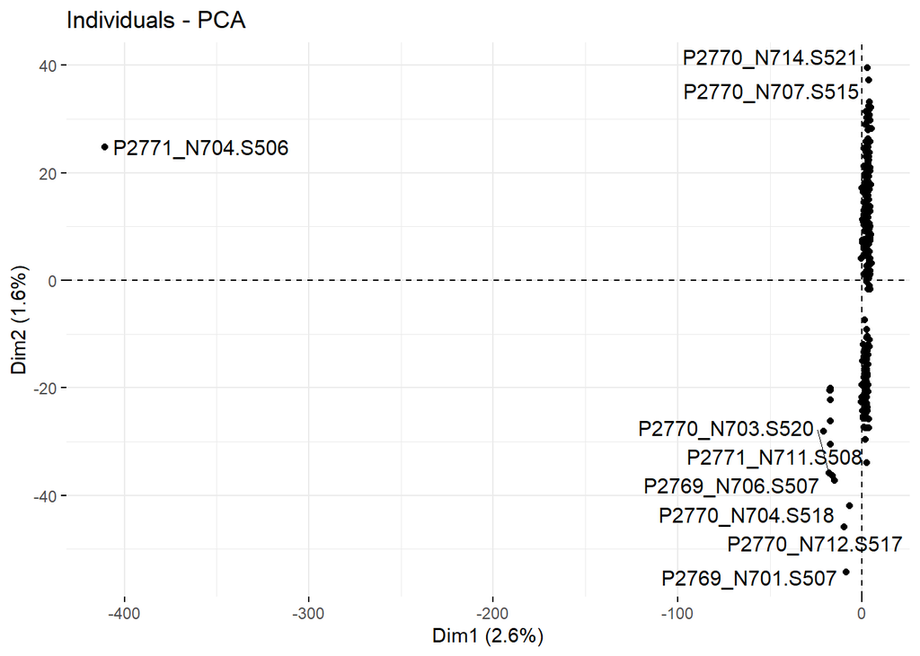

```r
#label the points to check the name of the outlier
factoextra::fviz_pca_ind(normpca, repel= "TRUE")
```

```r
#remove the outlier
X2 <- X1[!(row.names(X1) == "P2771_N704.S506"),]
data2 <- data[!(row.names(data) == "P2771_N704.S506"),]
treat2 <- treat[!(row.names(treat) == "P2771_N704.S506"),]
```

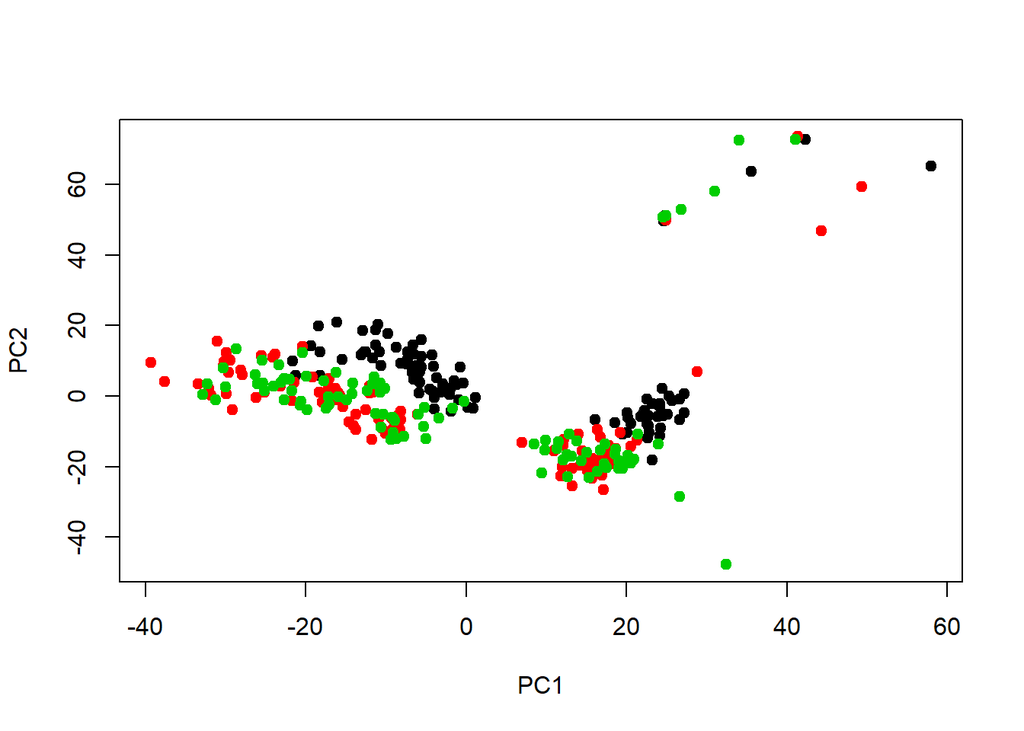

```r
#produce new PCA
X2=X2[, colSums(X2)>0]
Y2 = X2/rowSums(X2)
normpca <- stats::prcomp(Y2, scale=TRUE)
#colored by experiment
plot(normpca$x, pch=19, col=data2$experiment)
```

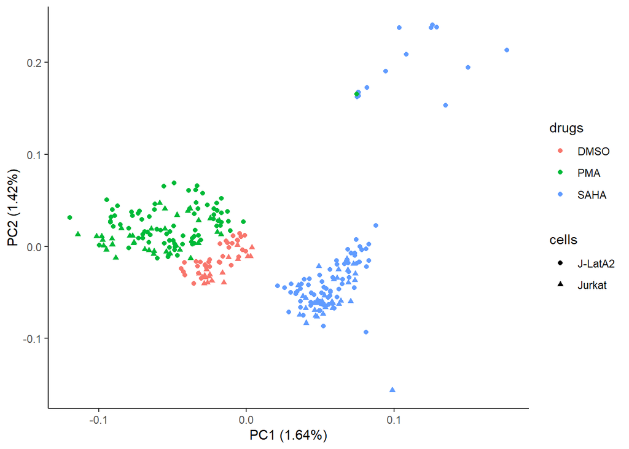

```r
#colored by treatment, using autoplot
ggplot2::autoplot(normpca, data=data2, colour="drugs", shape = "cells") + theme_classic()
```

DMSO is the control and it’s very similar to PMA, meaning that PMA doesn’t have a significant effect. On the other hand, SAHA is very different from both of them, meaning that it has a significant effect. There is no batch effect, because in the graph colored by experiment the samples are not clustered based on the experiment that they’re part of. However, we scaled the PCA and the scaled PCAs are more precise

```r
#tSNE
tsne1 <- Rtsne(X1)

## Check results generated
names(tsne1)
```

```
##  [1] "N"                   "Y"                   "costs"
##  [4] "itercosts"           "origD"               "perplexity"
##  [7] "theta"               "max_iter"            "stop_lying_iter"
## [10] "mom_switch_iter"     "momentum"            "final_momentum"
## [13] "eta"                 "exaggeration_factor"
```

```r
head(tsne1$Y)
```

```
##            [,1]       [,2]
## [1,]  4.9146423 -2.2539663
## [2,]  0.7963188 11.0268339
## [3,]  2.5069621 -4.1151162
## [4,] -2.2399334  1.0101384
## [5,]  6.2186611  0.4965871
## [6,]  5.6519080 -1.4887502
```

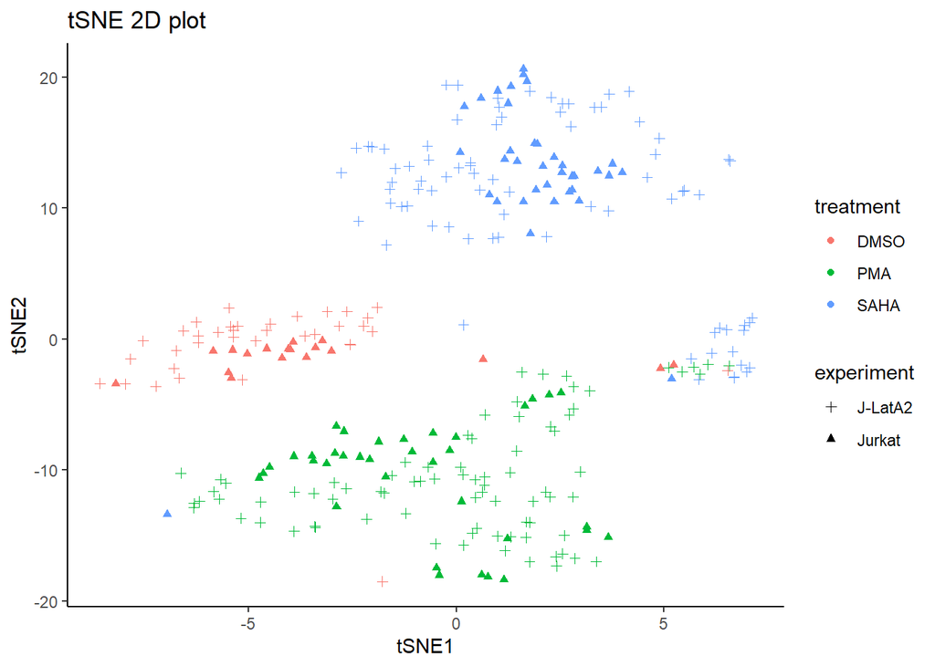

```r
tsne_data <- as.data.frame(tsne1$Y)
tsne_data$experiment <- data$cells
tsne_data$treatment <- data$drugs

## ggplot
ggplot(tsne_data, aes(x=V1, y=V2)) +
  geom_point(aes(color=treatment, shape=experiment)) +
  scale_shape_manual(values = c(3,17, 6)) +
  ggtitle("tSNE 2D plot") + xlab("tSNE1") + ylab("tSNE2") +
  theme_classic()
```

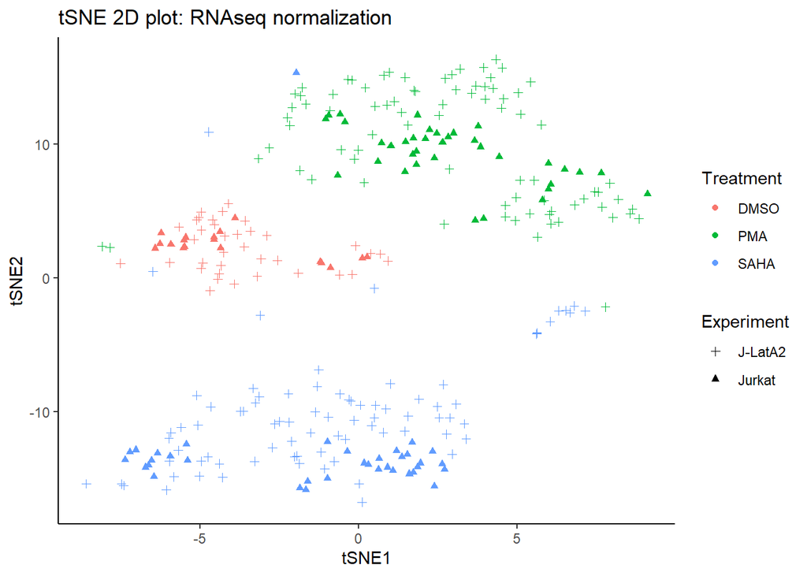

```r
## Normalized tSNE
X1=X1[, colSums(X1)>0]
Y = X1/rowSums(X1)
tSNE_norm <- Rtsne(Y, pca=TRUE)
tsne_data2 <- as.data.frame(tSNE_norm$Y)
tsne_data2$Experiment <- data$cells
tsne_data2$Treatment <- data$drugs
## ggplot
tSNE2 <- ggplot(tsne_data2, aes(x=V1, y=V2)) +
  geom_point(aes(color=Treatment, shape=Experiment)) +
  scale_shape_manual(values = c(3,17,6)) +
  ggtitle("tSNE 2D plot: RNAseq normalization") + xlab("tSNE1") + ylab("tSNE2") + theme_classic()
print(tSNE2)
```

**QUESTION 4**

```
## [1] "tSNE perplexity=1"
```

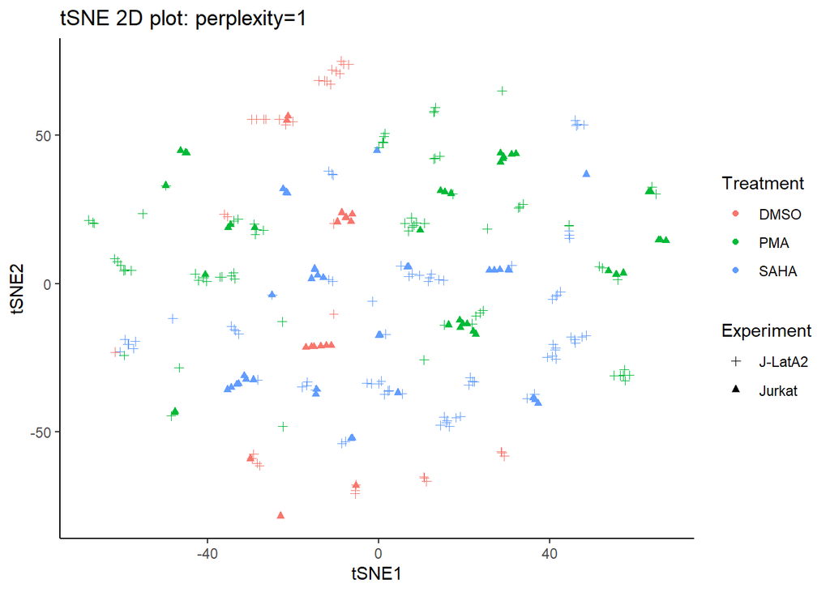

```
## [1] "tSNE perplexity=5"
```

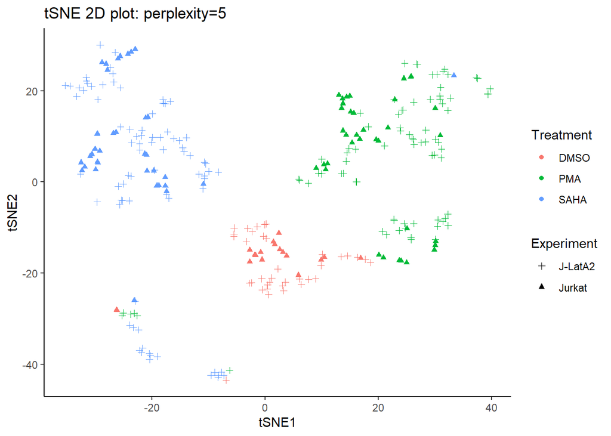

```
## [1] "tSNE perplexity=10"
```

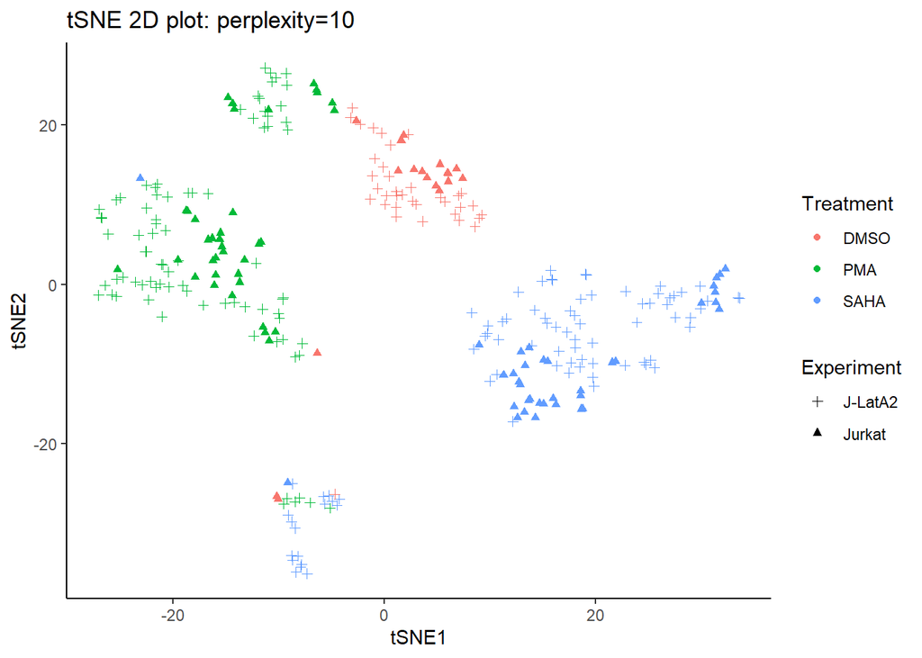

```
## [1] "tSNE perplexity=25"
```

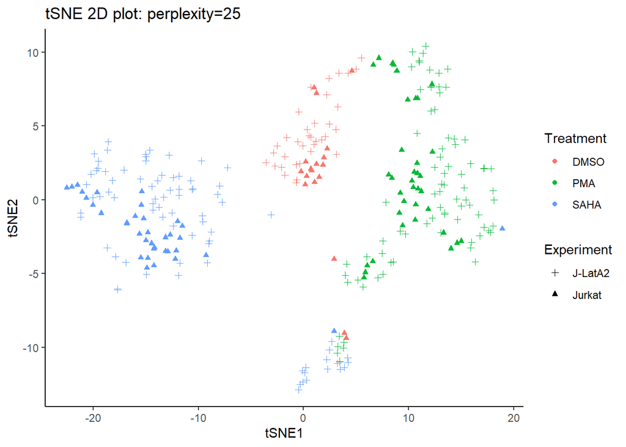

```
## [1] "tSNE perplexity=50"
```

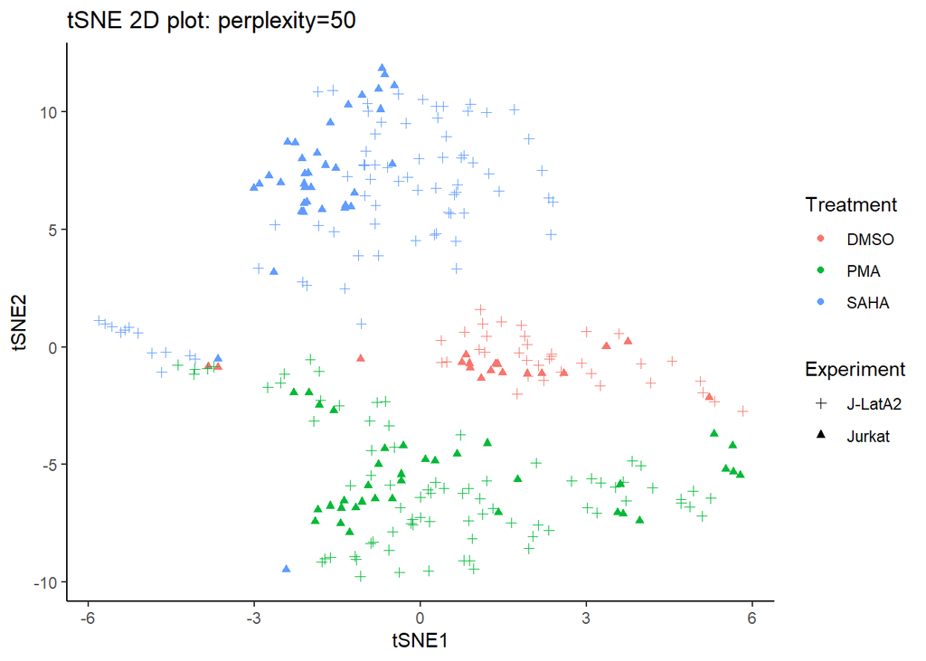

```r
#changing perplexity
set.seed(123) ## allows us to reproduce results

list_plots <- list()
for (p_value in c(1, 5, 10, 25, 50)) {
  print(paste0("tSNE perplexity=", p_value))

  ## Default parameters for Rtsne
  tsne_p <- Rtsne(X1, perplexity = p_value)

  tsne_data2 <- as.data.frame(tsne_p$Y)
  tsne_data2$Treatment <- data$drugs
  tsne_data2$Experiment <- data$cells

  ## ggplot
  plot_p <- ggplot(tsne_data2, aes(x=V1, y=V2)) +
    geom_point(aes(color=Treatment, shape=Experiment)) +
    scale_shape_manual(values = c(3,17,6)) +
    ggtitle(paste0("tSNE 2D plot: perplexity=", p_value)) + xlab("tSNE1") + ylab("tSNE2") +
    theme_classic()

  print(plot_p)

  # alternative: save plots in list_plots
  list_plots[[paste0("perp_", p_value)]] = plot_p
}
```

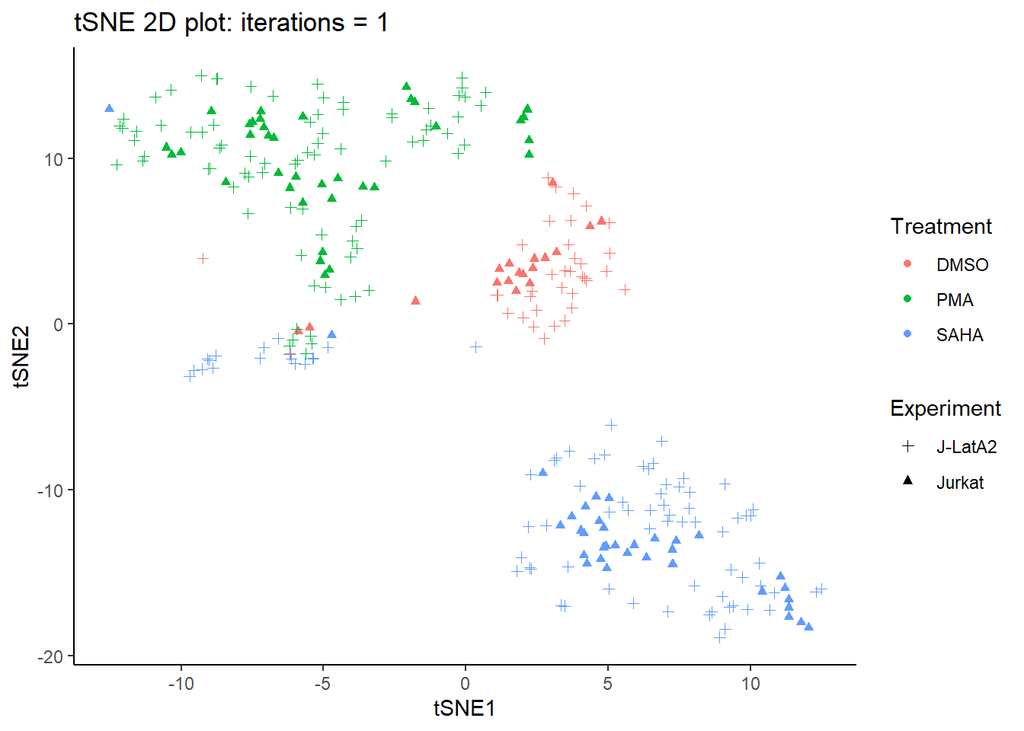

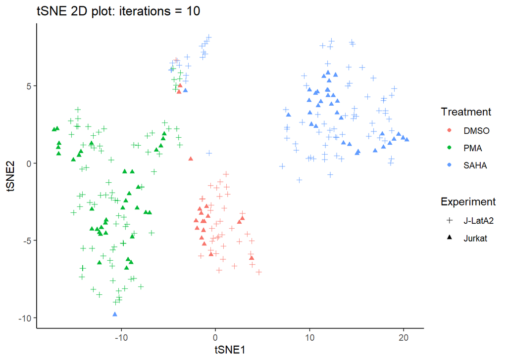

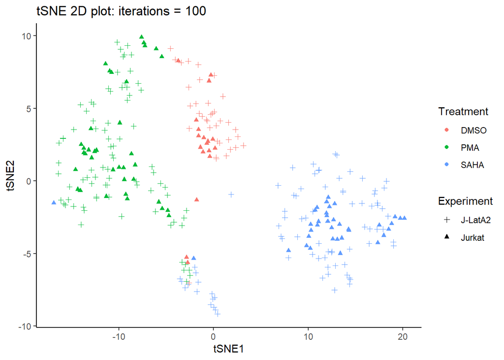

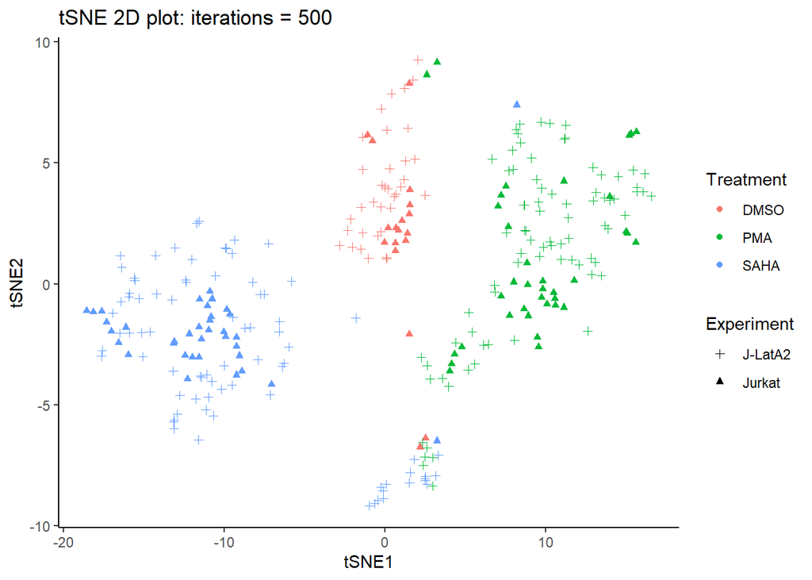

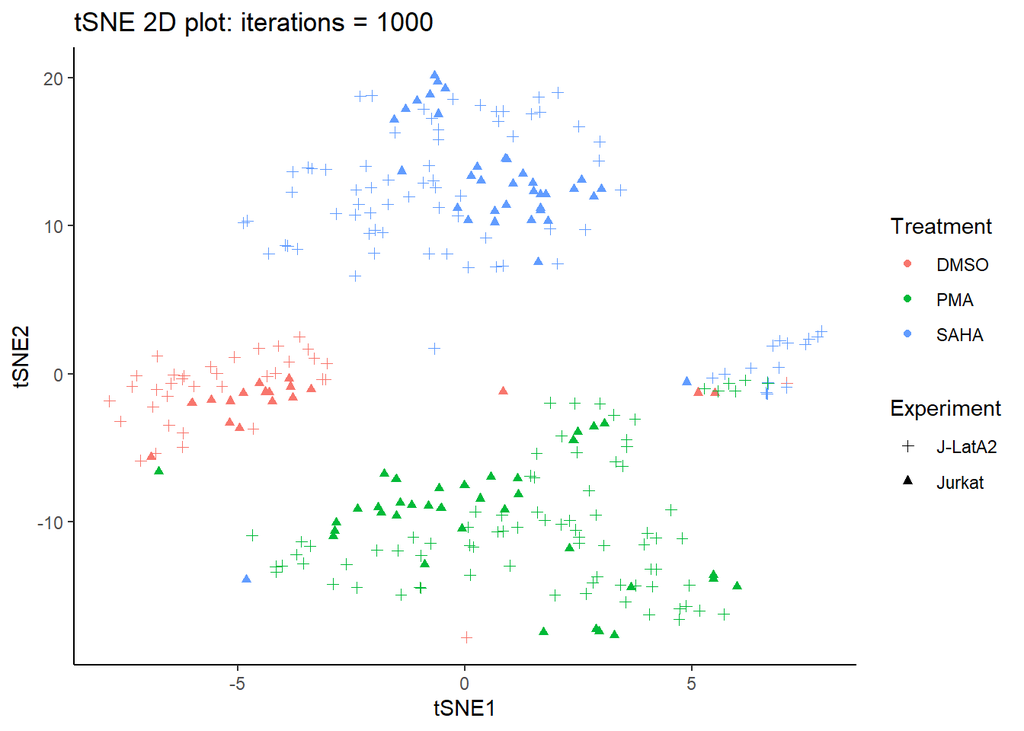

```r
#changing max_iterations
set.seed(123) ## allows us to reproduce results

for (max_iter in c(1, 10, 100, 500, 1000)) {
  tsne <- Rtsne(X1)

  tsne_data <- as.data.frame(tsne$Y)
  tsne_data$Experiment <- data$cells
  tsne_data$Treatment <- data$drugs

  library(ggplot2)
  p <- ggplot(tsne_data, aes(x=V1, y=V2)) +
   geom_point(aes(color=Treatment, shape=Experiment)) +
   scale_shape_manual(values = c(3,17,6)) +
   ggtitle(paste("tSNE 2D plot: iterations =", max_iter)) + xlab("tSNE1") + ylab("tSNE2") +
   theme_classic()
  print(p)
}
```

**QUESTION 5**

No, it is pretty clear from both the PCA and the tSNE graphs that SAHA and PMA have a different effect on the cells as the points associated to each drug are grouped very distinctly in two separate clusters. In particular, from the PCA plot we see that PMA treated cells are observed to be closer in similarity to DMSO (control) cells, so we might assume that PMA has a smaller effect than SAHA.

**QUESTION 6**

The PC1 separates differently treated cells, having SAHA treated cells on the right and DMSO and PMA on the left, indicating similarity between the control group and PMA treated cells, thus showing lower effectiveness in the PMA drug. Meanwhile PC2 separates dead from alive cells. On the top of the plot we have a few cells with low expression of genes (dead), on the lower half instead we have cells with high expression (alive).

**QUESTION 8**

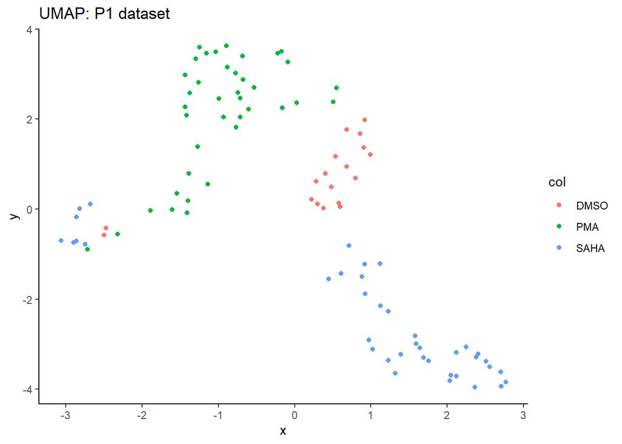

```r
#define a function to plot the results
plot_representation <- function(x_given, y_given, data, title) {
  data_plot <- data.frame(x = x_given,
                          y = y_given,
                          col = data
                          )

  p <- ggplot(data_plot) + geom_point(aes(x=x, y=y, color=col)) +
    ggtitle(title) + theme_classic()

  return(p)
}

#generate UMAP for first replicate
p1_dataSet_UMAP <- umap::umap(X3)

UMAP_plot1 <- plot_representation(p1_dataSet_UMAP$layout[,1],
                    p1_dataSet_UMAP$layout[,2],
                    treat$drugs,
                    "UMAP: P1 dataset")
print(UMAP_plot1)
```

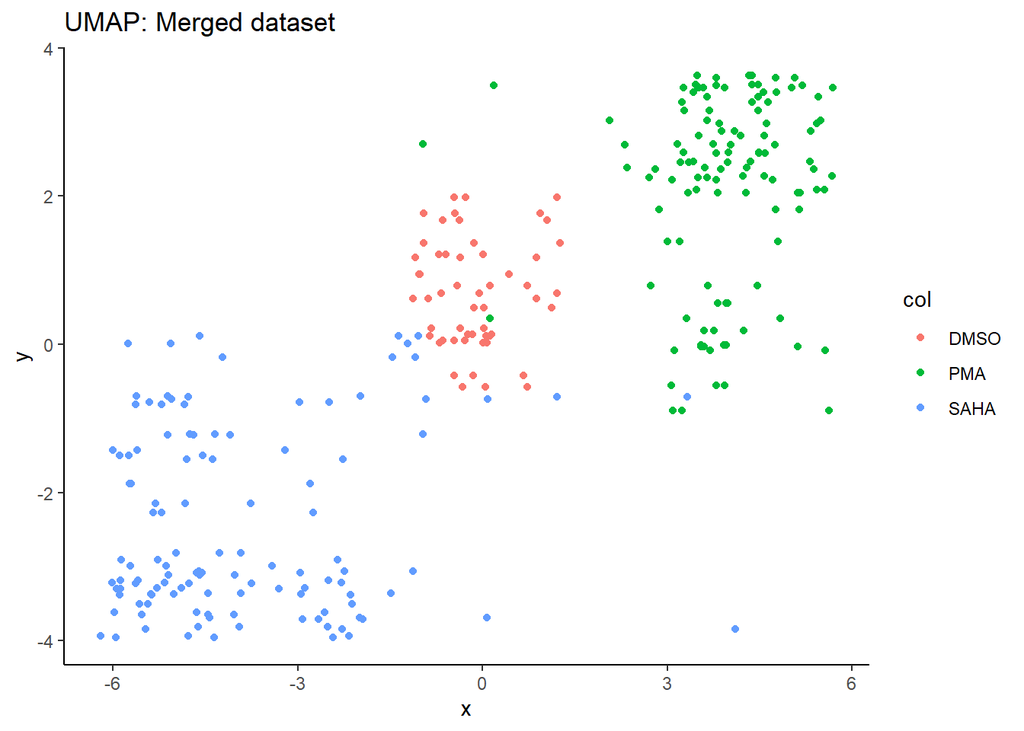

```r
#generate UMAP for merged and normalized datasets
pmerged_dataSet_UMAP <- umap::umap(Y1)

UMAP_plot2 <- plot_representation(pmerged_dataSet_UMAP$layout[,1],
                    p1_dataSet_UMAP$layout[,2],
                    treat$drugs,
                    "UMAP: Merged dataset")
print(UMAP_plot2)
```

**QUESTION 9**

```
## [1] "UMAP min_dist=0.1"
```

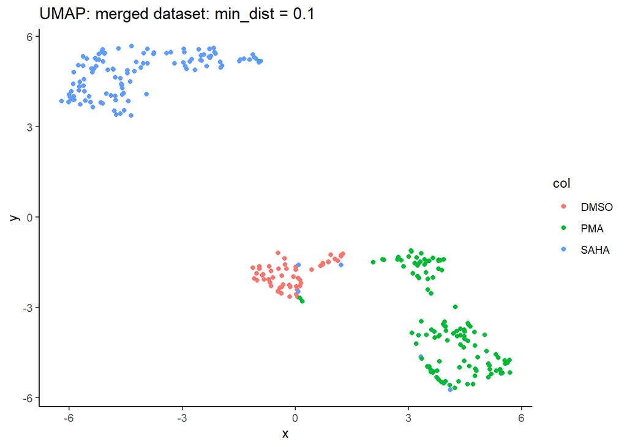

```
## [1] "UMAP min_dist=0.5"
```

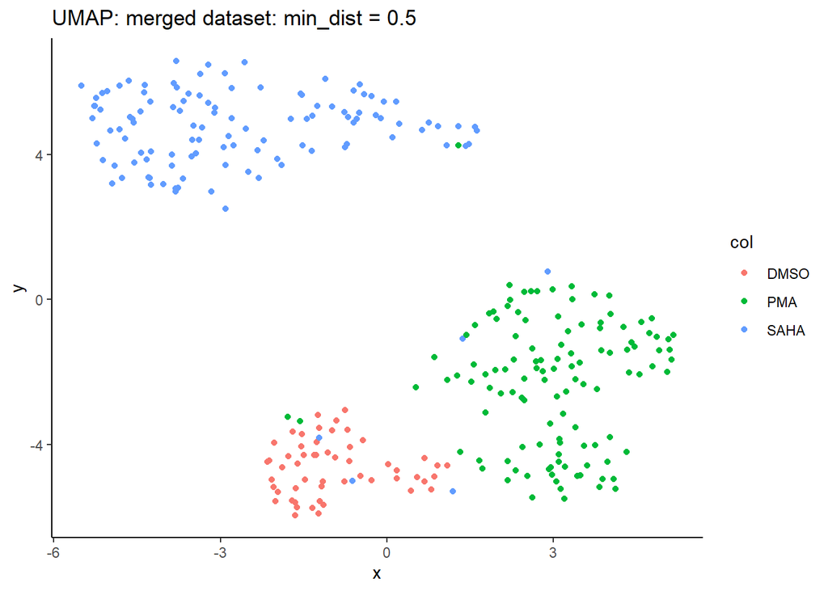

```
## [1] "UMAP min_dist=0.9"
```

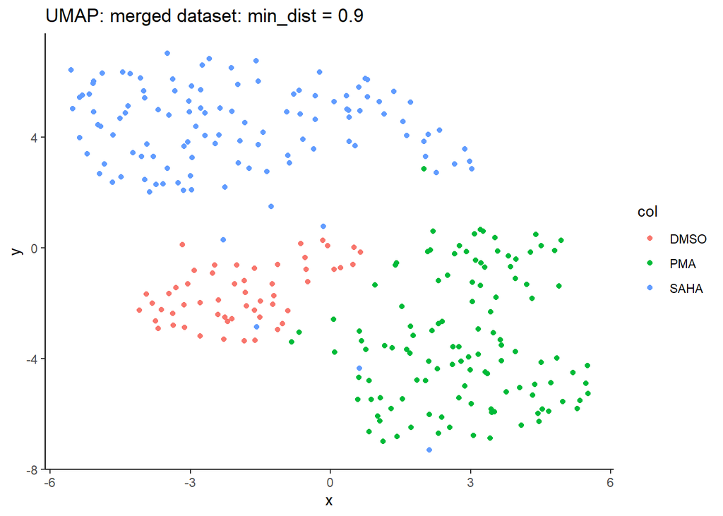

```r
#Explore minimum distance values
custom.umap.config <- umap::umap.defaults

custom.umap.config$n_neighbors = umap::umap.defaults$n_neighbors

for (min_dist_values in c(0.1,0.5,0.9)) {
  print(paste0("UMAP min_dist=", min_dist_values))

  custom.umap.config$min_dist = min_dist_values

  umap_n <- umap(Y, config = custom.umap.config)

  UMAP_plot <- plot_representation(umap_n$layout[,1],
                    umap_n$layout[,2],
                    treat$drugs,
                    paste0("UMAP: merged dataset: min_dist = ", min_dist_values))

  print(UMAP_plot)
}
```